# Chapter08. 상관된 오차항의 문제

Jeong-Eun Lee

2021 7 20

### 8.1 소개: 자기상관

- 자기상관 : 관측값들이 얻어지는 순서에 따라 그들이 서로 연관되어 있는 경우 오차항들은 자기상관을 가짐
  - 발생이유
    1. 시간적, 공간적으로 인접해있는 관측개체들에 대한 오차항들은 유사항 경향을 가지기 쉬움
    2. 공간적으로 인접한 실험구역에서 얻은 관측값들은 공유하는 외적 환경의 영향으로 상관된 잔차를 가지는 경향이 있음
- 오차항의 자기 상관성의 영향
  1. 최소제곱추정량이 더이상 최소분산을 가지지 않는다는 점에서 추정량의 효율성이 떨어짐
  2. $\sigma^2$이나 모회귀계수의 표준오차의 추정량은 실제보다 심각하게 과소추정될 수 있고 이에 따라 추정된 회귀계수는 그의 정확도가 높은 것으로 잘못 판단될 수 있음
  3. 통상적으로 사용되는 신뢰구간이나 유의성 검정 등이 엄격한 의미에서 더이상 타당하지 않음
- 자기상관성 문제의 유형
  1. 회귀모형에 포함되어야 할 예측변수가 빠짐으로써 생기는 경우 -> 해당 예측변수를 찾아내면 해결됨
  2. 순수자기상관 -> 데이터의 변환 등을 통해 해결

### 8.2 소비자 지출액과 통화량 데이터

```r
sc = read.table("C:\\Users\\X-Note\\Desktop\\Spending_Currency.txt", header = T)
head(sc)
```

```
##   Year Quarter Expenditure Stock
## 1 1952       1       214.6 159.3
## 2 1952       2       217.7 161.2
## 3 1952       3       219.6 162.8
## 4 1952       4       227.2 164.6
## 5 1953       1       230.9 165.9
## 6 1953       2       233.3 167.9
```

```r
lm_sc = lm(Expenditure ~ Stock, data = sc)
summary(lm_sc)
```

```
##
## Call:
## lm(formula = Expenditure ~ Stock, data = sc)
##
## Residuals:
##    Min     1Q Median     3Q    Max
## -7.176 -3.396  1.396  2.928  6.361
##
## Coefficients:
##              Estimate Std. Error t value Pr(>|t|)
## (Intercept) -154.7192    19.8500  -7.794 3.54e-07 ***
## Stock          2.3004     0.1146  20.080 8.99e-14 ***
## ---
## Signif. codes:  0 '***' 0.001 '**' 0.01 '*' 0.05 '.' 0.1 ' ' 1
##
## Residual standard error: 3.983 on 18 degrees of freedom
## Multiple R-squared:  0.9573, Adjusted R-squared:  0.9549
## F-statistic: 403.2 on 1 and 18 DF,  p-value: 8.988e-14
```

- 변수 : Y - 소비자 지출액, X - 통화량
- 이 데이터는 시간에 따라 순서적으로 얻어졌기에 자기상관의 존재를 의심할 수 있음

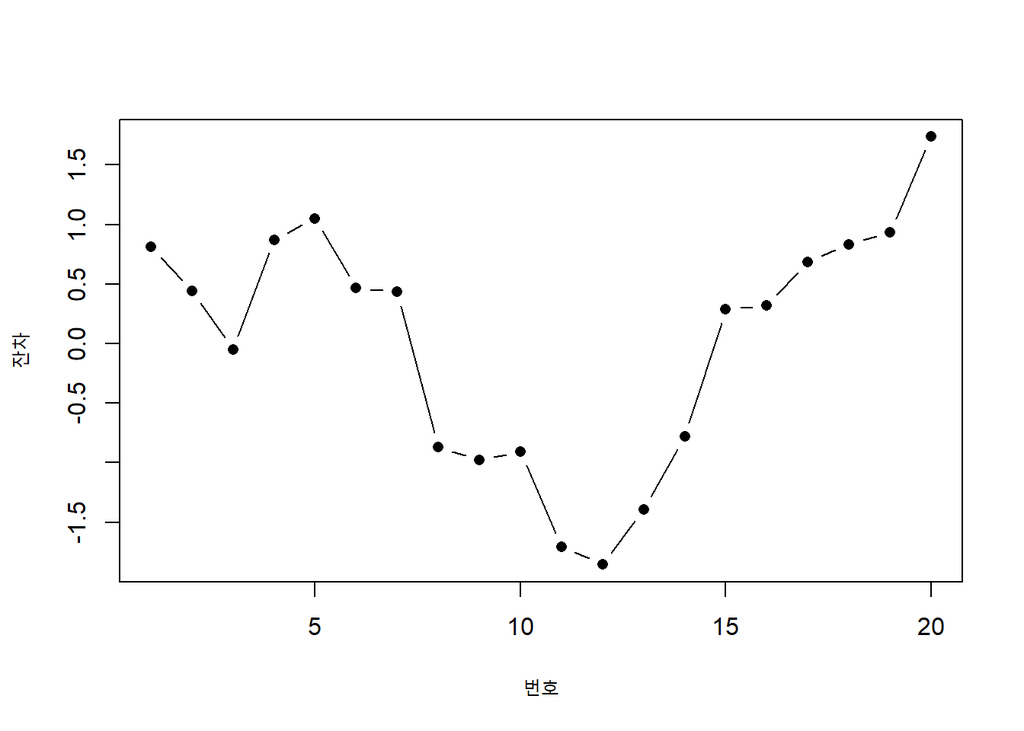

```r
plot(rstandard(lm_sc), xlab = "번호", ylab = "잔차", pch = 16, type = "b")
```

```r
(10.1-3)/sqrt(1.97)
```

```
## [1] 5.058541
```

### 8.4 변환을 통한 자기상관성의 제거

- Cochrane-Orcutt 방법
  $$\epsilon_t = y_t - \beta_0 - \beta_1x_t$$
  $$\epsilon_{t-1} = y_{t-1} - \beta_0 - \beta_1x_{t-1}$$
  $$y_t - \beta_0 - \beta_1x_t = \rho(y_{t-1} - \beta_0 - \beta_1x_{t-1}) + w_t$$
  $$y_t - \rho y_{t-1} = \beta_0(1-\rho) + \beta_1(x_t - \rho x_{t-1}) + w_t$$
  $$y_t^* = \beta_0^* + \beta_1^* x_t^* + w_t$$
  - $y_t^*$를 반응변수로, $x_t^*$를 예측변수로 하는 OLS를 수행하면 됨
- Cochrane-Orcutt의 반복적 추정절차
  1. 원데이터로부터 모형 $y_t = \beta_0 + \beta_1x_t + \epsilon_t$를 적합하여 _0, _1의 OLS 추정량을 계산한다.
  2. 1)의 결과로 잔차를 계산하고, 잔차로부터 추정한다.
  3. 변환된 변수로 $(y_t - \hat{\rho}y_{t-1})$와 $(x_t - \hat{\rho}x_{t-1})$을 사용하여 $y_t^* = \beta_0^* + \beta_1^* x_t^* + w_t$를 적합시키고 $\hat{\beta_0}, \hat{\beta_1}$을 얻는다.
  4. 새로 적합된 회귀식에서의 잔차들을 검토한다. 새로운 잔차들이 자기상관을 계속 보인다면 추정치 $\hat{\beta_0}, \hat{\beta_1}$을 사용하여 위의 과정을 반복 수행한다. 만일 새로운 잔차에 자기상관이 보이지 않으면 분석은 끝나고 원데이터에는 $\hat{y_t} = \hat{\beta_0} + \hat{\beta_1}x_t$로 적합된다.
- 8.2절의 데이터에 대한 Cochrane-Orcutt의 반복적 추정절차 적용 단계 1)

```r
lm_sc = lm(Expenditure ~ Stock, data = sc)
summary(lm_sc)
```

```
##
## Call:
## lm(formula = Expenditure ~ Stock, data = sc)
##
## Residuals:
##    Min     1Q Median     3Q    Max
## -7.176 -3.396  1.396  2.928  6.361
##
## Coefficients:
##              Estimate Std. Error t value Pr(>|t|)
## (Intercept) -154.7192    19.8500  -7.794 3.54e-07 ***
## Stock          2.3004     0.1146  20.080 8.99e-14 ***
## ---
## Signif. codes:  0 '***' 0.001 '**' 0.01 '*' 0.05 '.' 0.1 ' ' 1
##
## Residual standard error: 3.983 on 18 degrees of freedom
## Multiple R-squared:  0.9573, Adjusted R-squared:  0.9549
## F-statistic: 403.2 on 1 and 18 DF,  p-value: 8.988e-14
```

단계 2)

```r
re_t = lm_sc$residuals
re_t
```

```
##          1          2          3          4          5          6          7
##  2.8701152  1.5994109 -0.1811822  3.2781506  3.9876688  1.7869275  1.6667792
##          8          9         10         11         12         13         14
## -3.3537397 -3.7940363 -3.5244440 -6.6152965 -7.1761120 -5.3468163 -2.9772240
##         15         16         17         18         19         20
##  1.0923683  1.1919976  2.5718494  3.1015158  3.4612192  6.3608486
```

```r
k = 0
for(j in 2:length(re_t)){
  k[j-1] = (re_t[j]-re_t[j-1])^2
}
d = sum(k)/sum(re_t^2)
d
```

```
## [1] 0.3282113
```

```r
g = 0
for(j in 2:length(re_t)){
  g[j-1] = (re_t[j] * re_t[j-1])
}
rho_h = sum(g) / sum(re_t^2)
rho_h
```

```
## [1] 0.7506122
```

단계 3)

```r
y2 = 0
for(t in 1:length(sc$Stock)){
  y2[t-1] = sc$Expenditure[t] - rho_h * sc$Expenditure[t-1]
}
y2
```

```
##  [1] 56.61861 56.19171 62.36555 60.36090 59.98363 58.98216 56.58167 59.33277
##  [9] 61.08192 61.18020 64.02886 66.85110 67.09731 70.01931 67.46526 67.96380
## [17] 68.83739 69.08580 72.63445
```

```r
x2 = 0
for(t in 1:length(sc$Stock)){
  x2[t-1] = sc$Stock[t] - rho_h * sc$Stock[t-1]
}
x2
```

```
##  [1] 41.62747 41.80131 42.40033 42.34922 43.37343 42.27220 43.37196 43.12110
##  [9] 43.62061 45.09494 45.56853 45.81718 45.49102 45.76535 45.93967 45.58906
## [17] 46.18882 46.31326 46.71278
```

```r
lm_sc2 = lm(y2 ~ x2)
summary(lm_sc2)
```

```
##
## Call:
## lm(formula = y2 ~ x2)
##
## Residuals:
##     Min      1Q  Median      3Q     Max
## -4.3737 -0.7856  0.2747  1.0408  3.9786
##
## Coefficients:
##             Estimate Std. Error t value Pr(>|t|)
## (Intercept) -53.6959    13.6164  -3.943  0.00105 **
## x2            2.6434     0.3069   8.614 1.32e-07 ***
## ---
## Signif. codes:  0 '***' 0.001 '**' 0.01 '*' 0.05 '.' 0.1 ' ' 1
##
## Residual standard error: 2.263 on 17 degrees of freedom
## Multiple R-squared:  0.8136, Adjusted R-squared:  0.8026
## F-statistic:  74.2 on 1 and 17 DF,  p-value: 1.315e-07
```

- 위의 적합으로 얻은 회귀 적합식은 $\hat{y_t}^* = -53.70 + 2.64x_t^*$이다.
- 이를 원변수의 항으로 적합식을 바꾸면 $\hat{y_t} = -215.31 + 2.64x_t$가 된다.

단계 4)

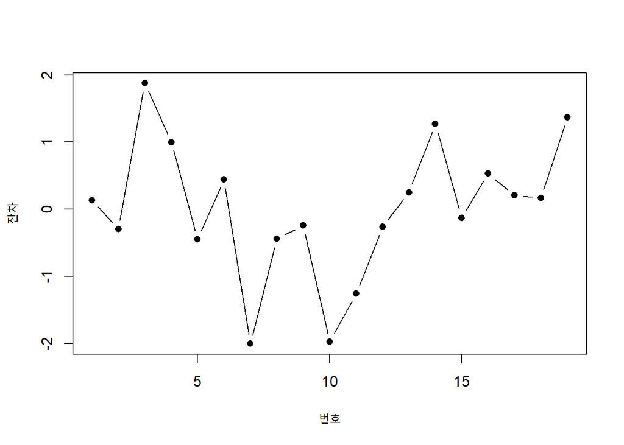

```r
plot(rstandard(lm_sc2), xlab = "번호", ylab = "잔차", pch = 16, type = "b")
```

- 잔차플롯을 보면 부호별로 인접해있던 잔차들이 전보다는 좀 덜 모여있는 형태를 띠고 있어 Cochrane-Orcutt의 방법이 작동되고 있음을 알 수 있다.

### 8.5 자기상관된 오차항에 대한 반복적 추정방법

- Cochrane-Orcutt의 장점 : 최소제곱법에 의해 모수의 추정값이 구해지므로 그 절차가 비교적 단순함
- Cochrane-Orcutt의 단점 : 이단계 처리가 필요함

### 8.6 자기상관성과 결손된 예측변수

- 새로운 예측변수의 도입 가능성을 타진해보는 것이 더 바람직할 때가 많음
  - 그 예측변수가 가지는 주변효과의 추정 + 그 예측변수가 반응변수에 대해 가지는 정보를 활용할 수 있음

### 8.7 주택착공데이터

- 변수 : H - 주택착공수, P - 인구수, D - 담보융자자금
- 분석 목적 : 주택착공수와 인구 사이의 단순선형회귀모형을 구축하는 것 -> $H_t = \beta_0 + \beta_1P_t + \epsilon$

```r
house = read.table("C:\\Users\\X-Note\\Desktop\\housing_starts.txt", header = T)
head(house)
```

```
##         H     P       D
## 1 0.09090 2.200 0.03635
## 2 0.08942 2.222 0.03345
## 3 0.09755 2.244 0.03870
## 4 0.09550 2.267 0.03745
## 5 0.09678 2.280 0.04063
## 6 0.10327 2.289 0.04237
```

```r
lm_house1 = lm(H ~ P, data = house)
summary(lm_house1)
```

```
##
## Call:
## lm(formula = H ~ P, data = house)
##
## Residuals:
##        Min         1Q     Median         3Q        Max
## -0.0083683 -0.0021329  0.0005252  0.0025572  0.0080754
##
## Coefficients:
##              Estimate Std. Error t value Pr(>|t|)
## (Intercept) -0.060884   0.010416  -5.845 5.89e-06 ***
## P            0.071410   0.004234  16.867 1.91e-14 ***
## ---
## Signif. codes:  0 '***' 0.001 '**' 0.01 '*' 0.05 '.' 0.1 ' ' 1
##
## Residual standard error: 0.00408 on 23 degrees of freedom
## Multiple R-squared:  0.9252, Adjusted R-squared:  0.922
## F-statistic: 284.5 on 1 and 23 DF,  p-value: 1.911e-14
```

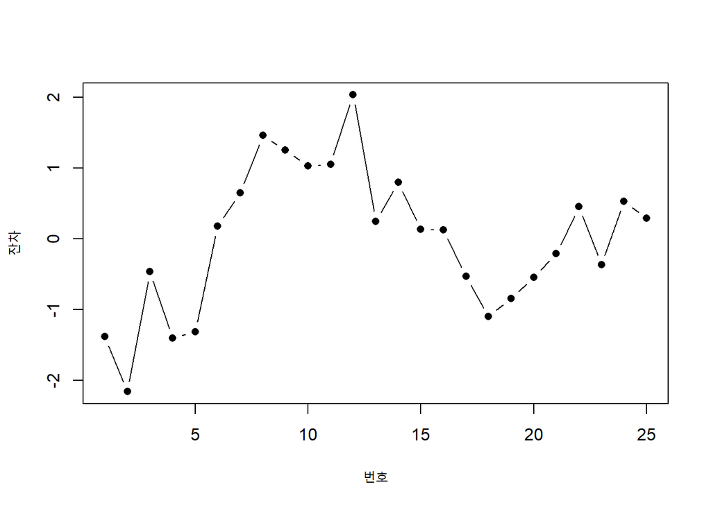

```r
plot(rstandard(lm_house1), xlab = "번호", ylab = "잔차", pch = 16, type = "b")
```

```r
lm_house2 = lm(H ~ P + D, data = house)
summary(lm_house2)
```

```
##
## Call:
## lm(formula = H ~ P + D, data = house)
##
## Residuals:
##        Min         1Q     Median         3Q        Max
## -0.0067091 -0.0017000  0.0007819  0.0019446  0.0032143
##
## Coefficients:
##              Estimate Std. Error t value Pr(>|t|)
## (Intercept) -0.010427   0.010291  -1.013    0.322
## P            0.034656   0.006425   5.394 2.04e-05 ***
## D            0.760464   0.121588   6.254 2.70e-06 ***
## ---
## Signif. codes:  0 '***' 0.001 '**' 0.01 '*' 0.05 '.' 0.1 ' ' 1
##
## Residual standard error: 0.002503 on 22 degrees of freedom
## Multiple R-squared:  0.9731, Adjusted R-squared:  0.9706
## F-statistic: 397.6 on 2 and 22 DF,  p-value: < 2.2e-16
```

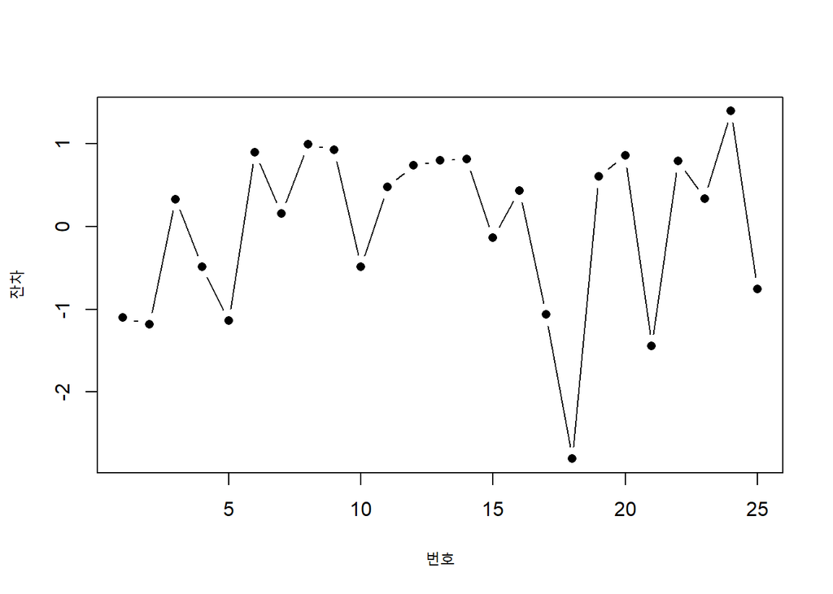

```r
plot(rstandard(lm_house2), xlab = "번호", ylab = "잔차", pch = 16, type = "b")
```

- 예측변수 D를 모형에 추가함으로써 오차항의 자기상관성의 문제가 제거되는 효과를 얻었고 잔차플롯도 많이 개선됨
  - 인구수를 고정시킬 때 담보융자자금의 변화가 고정된 담보융자자금에 대한 인구수의 변이보다 주택건설활동에 더 중요한 영향을 미침 -> 담보융자자금의 지표가 인구수보다 주택 착공수에 더 큰 효과가 있음
- 이 데이터 분석의 시사점
  1. 큰 $R^2$ 값이 곧 데이터가 잘 적합되었고, 설명이 잘 되었다는 것을 뜻하지 않음
  2. 더빈-왓슨 통계량의 값이 유의하면, 결손된 예측변수가 있을 가능성이나 자기상관의 문제가 존재하는 증거가 됨

### 8.8 더빈-왓슨 통계량의 제한성

- 더빈-왓슨 통계량 & 잔차플롯 : 시간적으로 인접한 잔차들 사이에 나타나는 종속 관계를 보임
- 더빈-홧슨 통계량 vs 잔차플롯
  - 더빈-왓슨 통계량 : 오차항의 시간종속성이 2차 이상인 경우에 대해서는 특별히 유용한 정보를 제공한다고 할 수 없음
  - 잔차플롯 : 시간종속성이 1차가 아니더라도 오차항의 자기상관성에 대해 유용한 정보를 지님
- 스키판매액 데이터
  - 변수 : $S_t$ - 스키 판매량, $PDI_t$ - 개인 가처분 소득

```r
ski = read.table("C:\\Users\\X-Note\\Desktop\\ski.txt", header = T)
head(ski)
```

```
##    Date Sales PDI
## 1 Q1/64  37.0 109
## 2 Q2/64  33.5 115
## 3 Q3/64  30.8 113
## 4 Q4/64  37.9 116
## 5 Q1/65  37.4 118
## 6 Q2/65  31.6 120
```

```r
lm_ski = lm(Sales ~ PDI, data = ski)
summary(lm_ski)
```

```
##
## Call:
## lm(formula = Sales ~ PDI, data = ski)
##
## Residuals:
##    Min     1Q Median     3Q    Max
## -5.229 -2.686  0.554  2.728  4.454
##
## Coefficients:
##             Estimate Std. Error t value Pr(>|t|)
## (Intercept) 12.39215    2.53942    4.88 1.93e-05 ***
## PDI          0.19791    0.01602   12.35 7.09e-15 ***
## ---
## Signif. codes:  0 '***' 0.001 '**' 0.01 '*' 0.05 '.' 0.1 ' ' 1
##
## Residual standard error: 3.019 on 38 degrees of freedom
## Multiple R-squared:  0.8006, Adjusted R-squared:  0.7953
## F-statistic: 152.5 on 1 and 38 DF,  p-value: 7.089e-15
```

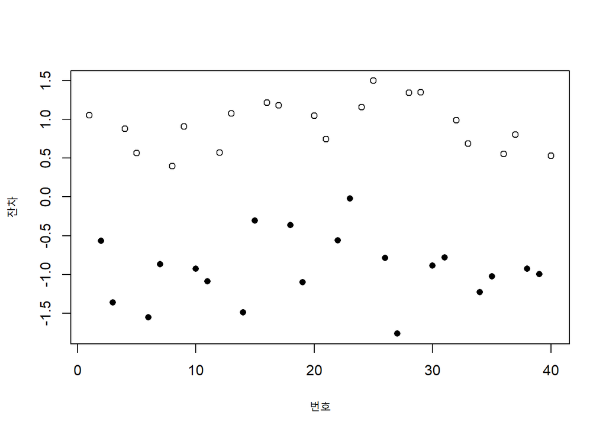

```r
plot(rstandard(lm_ski), xlab = "번호", ylab = "잔차", pch = 16, type = "n")
points(which(c(1:nrow(ski))%%4 %in% c(2,3)), rstandard(lm_ski)[c(1:nrow(ski))%%4 %in% c(2,3)], pch = 16)
points(which(c(1:nrow(ski))%%4 %in% c(0,1)), rstandard(lm_ski)[c(1:nrow(ski))%%4 %in% c(0,1)], pch = 1)
```

- 1, 4분기의 잔차는 양(+), 2, 3분기의 잔차는 음(-) -> 오차항들에 분명한 시간 종속성이 있음

### 8.9 계절성을 제거하기 위한 가변수의 이용

- 겨울철은 1, 여름철은 0으로 하여 가변수 $Z_t$를 취하면 $S_t = \beta_0 + \beta_1PDI_t + \beta_2Z_t + \epsilon$
  - 겨울철($Z_t = 1$) : $S_t = (\beta_0 + \beta_2) + \beta_1PDI_t + \epsilon$
  - 여름철($Z_t = 0$) : $S_t = \beta_0 + \beta_1PDI_t + \epsilon$

```r
library(tidyr)
ski_2 = separate(data = ski, col = Date, sep = "/", into = c("month", "year"))
ski_3 = transform(ski_2,
                Z = ifelse((ski_2$month == "Q1")|(ski_2$month == "Q4"), 1, 0))
head(ski_3)
```

```
##   month year Sales PDI Z
## 1    Q1   64  37.0 109 1
## 2    Q2   64  33.5 115 0
## 3    Q3   64  30.8 113 0
## 4    Q4   64  37.9 116 1
## 5    Q1   65  37.4 118 1
## 6    Q2   65  31.6 120 0
```

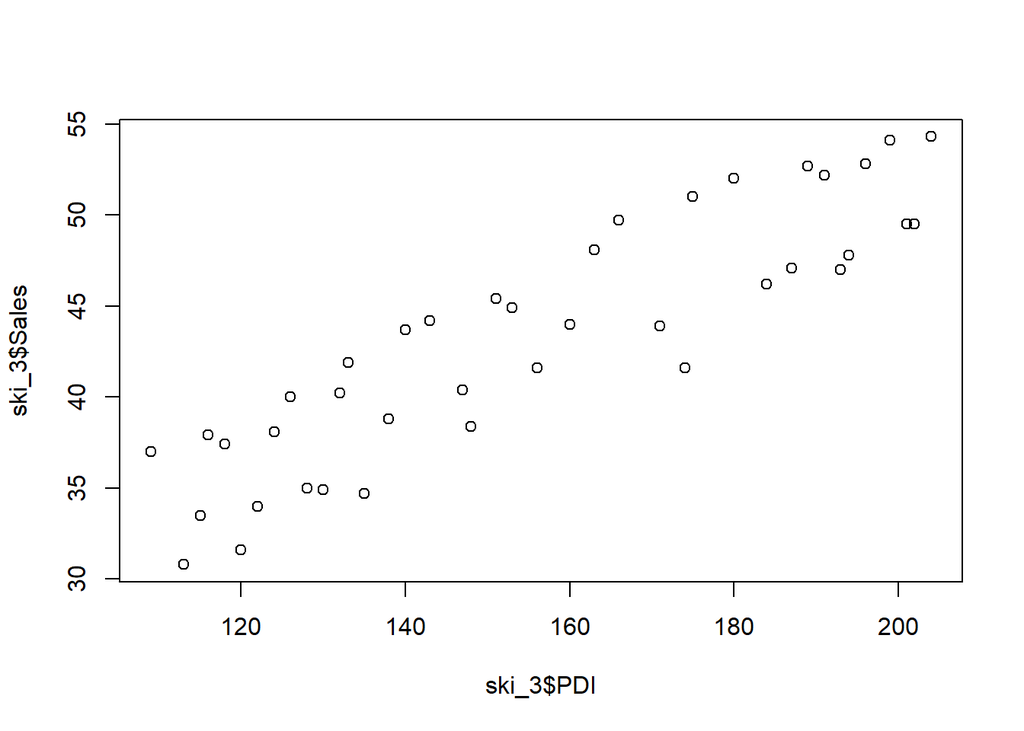

```r
plot(ski_3$PDI, ski_3$Sales)
```

- 두 계절에 대한 회귀직선은 평행하며 PDI의 변화에 대한 주변 효과는 두 계절이 같음
- 절편에 의해 반영되는 스키 판매액의 수준은 계절별로 다름

```r
lm_ski = lm(Sales ~ PDI + Z, data = ski_3)
summary(lm_ski)
```

```
##
## Call:
## lm(formula = Sales ~ PDI + Z, data = ski_3)
##
## Residuals:
##      Min       1Q   Median       3Q      Max
## -2.51118 -0.78640  0.02632  0.72842  2.67040
##
## Coefficients:
##             Estimate Std. Error t value Pr(>|t|)
## (Intercept) 9.540202   0.974825   9.787 8.23e-12 ***
## PDI         0.198684   0.006036  32.915  < 2e-16 ***
## Z           5.464342   0.359682  15.192  < 2e-16 ***
## ---
## Signif. codes:  0 '***' 0.001 '**' 0.01 '*' 0.05 '.' 0.1 ' ' 1
##
## Residual standard error: 1.137 on 37 degrees of freedom
## Multiple R-squared:  0.9724, Adjusted R-squared:  0.971
## F-statistic: 652.9 on 2 and 37 DF,  p-value: < 2.2e-16
```

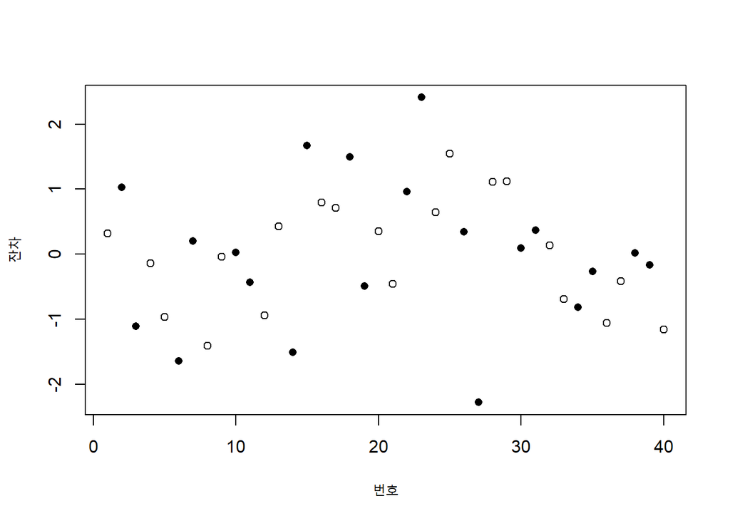

```r
plot(rstandard(lm_ski), xlab = "번호", ylab = "잔차", pch = 16, type="n")
points(which(c(1:nrow(ski))%%4 %in% c(2,3)), rstandard(lm_ski)[c(1:nrow(ski))%%4 %in% c(2,3)], pch = 16)
points(which(c(1:nrow(ski))%%4 %in% c(0,1)), rstandard(lm_ski)[c(1:nrow(ski))%%4 %in% c(0,1)], pch = 1)
```

- 위의 잔차플롯을 통해 계절성에 대한 모든 징후가 제거됨을 확인할 수 있음
- 이 데이터 분석의 시사점
  1. 더빈-왓슨 통계량은 인접된 관측값 사이에 상관관계가 있을 때만 민감함
  2. 유의적인 상관이 보이면 모형은 일단 재적합되어야 함

### 8.10 두 개의 시계열에 대한 회귀

- 시계열 데이터 vs 횡단면 데이터
  - 시계열 데이터 : 관측값들이 연속적인 시간에 의해 발생, 자기 상관의 개념은 매우 유의한 요소, 대부분 계절성을 띠고 있음, 스스로 어떤 경향성을 내포할 가능성이 많음
  - 횡단면 데이터 : 관측값들이 한 시점에서 동시에 생성, 자기 상관의 개념은 적절하지 않음
    - -> 시계열 데이터에 대한 회귀분석을 시도할 경우 분석자는 데이터에 있을지도 모를 가능한 오차항의 자기상관성과 계절성 요인을 검토하여야 함. 이때, 반응변수 또는 예측변수들의 계차값을 나타내는 변수를 모형에 포함시키는 것도 고려 대상이 됨

### chap8.2) 원유생산량데이터

- 표 6.19의 원유 생산량 데이터를 참조하여라. log(OIL)에 대한 선형회귀적합 후에 얻어진 잔차의 인덱스플롯은 반복적인 패턴이 있음을 보여주고 있다.

```r
oil = read.table("C:\\Users\\X-Note\\Desktop\\Oil.txt", header = T)
head(oil)
```

```
##   Year Barrels
## 1 1880      30
## 2 1890      77
## 3 1900     149
## 4 1905     215
## 5 1910     328
## 6 1915     432
```

1. 더빈-왓슨 통계량 d를 계산하여라. d로부터 자기상관 존재여부에 관한 결론을 도출하여라.

```r
lm_log_oil = lm(Year ~ log(Barrels), data = oil)
summary(lm_log_oil)
```

```
##
## Call:
## lm(formula = Year ~ log(Barrels), data = oil)
##
## Residuals:
##    Min     1Q Median     3Q    Max
## -5.142 -2.779 -1.276  1.325 10.051
##
## Coefficients:
##               Estimate Std. Error t value Pr(>|t|)
## (Intercept)  1818.7684     3.3316  545.91   <2e-16 ***
## log(Barrels)   15.9688     0.3987   40.05   <2e-16 ***
## ---
## Signif. codes:  0 '***' 0.001 '**' 0.01 '*' 0.05 '.' 0.1 ' ' 1
##
## Residual standard error: 4.132 on 27 degrees of freedom
## Multiple R-squared:  0.9834, Adjusted R-squared:  0.9828
## F-statistic:  1604 on 1 and 27 DF,  p-value: < 2.2e-16
```

```r
re_t = lm_log_oil$residuals
k = 0
for(j in 2:length(re_t)){
  k[j-1] = (re_t[j]-re_t[j-1])^2
}
d = sum(k)/sum(re_t^2)
d
```

```
## [1] 0.1875883
```

- log(OIL)에 대한 선형회귀적합 후 계산한 더빈-왓슨 통계량 d의 값은 약 0.188로 2에 가까운 수치라고 할 수 없다. 이 계산값은 오차항에는 자기상관관계가 존재한다는 증거가 되므로 원유생산량데이터에서는 자기상관성이 높다고 할 수 있다.
2. 연(run)의 수를 그 기댓값과 표준편차와 비교하여라. 이 비교를 통하여 자기상관 존재여부에 관한 결론을 도출하여라.

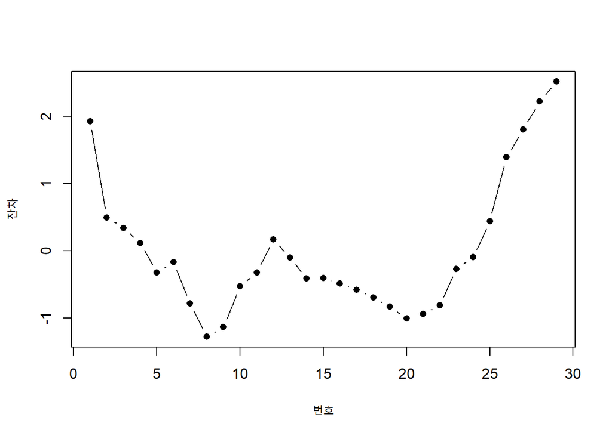

```r
plot(rstandard(lm_log_oil), xlab = "번호", ylab = "잔차", pch = 16, type = "b")
```

- 잔차에 대한 연(run)의 개수를 파악하기 위해 계열플롯을 작성해보면
  $$++++-------+------------+++++$$
  로 전체 5개의 연이 나타난다. 양의 잔차($n_1$) = 10, 음의 잔차($n_2$) = 19라는 점을 이용하여 연의 개수의 기댓값과 표준편차를 계산해보면,
  $$\mu = \frac {2 * 10 * 19} {10 + 19} + 1 = 14.10$$
  $$\sigma^2 = \frac {2 * 10 * 19 * (2 * 10 * 19 - 10 - 19)} {(10 + 19)^2(10 + 19 - 1)} = 5.66$$
- 연검정의 test statistic을 구하면

```r
(14.10 - 5) / sqrt(5.66)
```

```
## [1] 3.825015
```